# AFDMD-111 Estadística

Cálculo de probabilidad de VAs

# Variables aleatorias discretas

Como se ha mencionado en clases pasadas existen tres tipos de variables aleatorias; discretas, continuas y mixtas. Para nuestro curso, estaremos interesados en las variables aleatorias discretas y continuas. Recordemos que para las variables aleatorias discretas contamos con dos funciones que las describen totalmente; la función de distribución y la función de densidad. La función de distribución está dada por:
$$F_X(x) = P(X \le x)$$
para cualquier valor $x \in \mathbb{R}$. La función de masa de probabilidad es la otra función que se define de la siguiente manera:
$$p_X(k) = P(X=k)$$
Por lo tanto, cuando se nos dá una variable aleatoria discreta ésta está definida por una fórmula que representa $p_X(k)$ o $F_X(x)$. La variable aleatoria binomial, por ejemplo está dada por:
$$p_X(k) = \binom{n}{k}p^k(1-p)^{n-k}\; \;\;\; k=0,1,2, \ldots n$$
En R, los comandos `dbinom, pbinom, rbinom` y `qbinom` generan las pmfs, distribuciones y números aleatorios relacionados a la variable aleatoria discreta Binomial. Por ejemplo, el siguiente código genera $100$ números aleatorios de una distriubción binomial con parámetros $n=16$, $p=0.1$ y posteriormente se grafican.

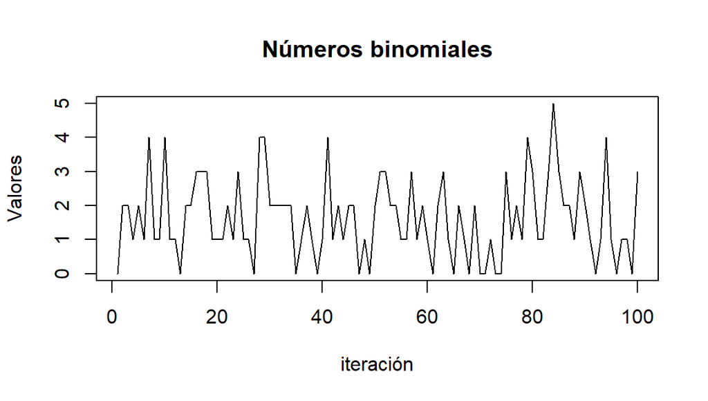

```r
vars <-rbinom(100, size=16, prob=0.1)
plot(vars, type="l", main="Números binomiales", xlab="iteración", ylab="Valores")
```

## Actividad

Investigue la generación de *pmfs* y *cdfs* discretas en R o python y posteriormente calcule las siguientes probabilidades usando únicamente código:

1. Sea $X$ una variable aleatoria que tiene distribución binomial con $p=0.4$ y $n=20$. Calcular:
1. $P(X\le 6)$
2. $P(X\ge 12)$
3. $P(X=8)$

```r
# Parámetros de la distribución binomial
p <- 0.4
n <- 20

# a. P(X <= 6)
prob_a <- pbinom(6, size = n, prob = p)

# b. P(X >= 12) = 1 - P(X < 12)
prob_b <- 1 - pbinom(11, size = n, prob = p)

# c. P(X = 8)
prob_c <- dbinom(8, size = n, prob = p)

list(prob_a, prob_b, prob_c)
```

```
## [[1]]
## [1] 0.2500107
##
## [[2]]
## [1] 0.05652637
##
## [[3]]
## [1] 0.1797058
```

2. El comando `sample`, me permite generar números aleatorios con una *pmf* que define el usuario. Generar 100 números aleatorios con las siguientes pmfs:
1. $p_X(k) = {5\choose k}\left(\frac{1}{5}\right)^k \left(\frac{4}{5}\right)^{5-k}, \;\; k=0,1,2,3,4,5.$
2. $p_X(k) = \frac{k^2}{2870}, \;\; k=0,1,2,3,\ldots, 19, 20$
3. $p_X(k) = \log_{10}\left(\frac{k+1}{k}\right)\; \; k=1,2,3, \ldots 9$

```r
# a. PMF
pmf_a <- choose(5, 0:5) * (1/5)^(0:5) * (4/5)^(5-(0:5))
# Generar 100 números aleatorios con PMF a
sample_a <- sample(0:5, 100, replace = TRUE, prob = pmf_a)

# b. PMF
pmf_b <- (0:20)^2 / 2870
# Generar 100 números aleatorios con PMF b
sample_b <- sample(0:20, 100, replace = TRUE, prob = pmf_b)

# c. PMF
pmf_c <- log10((1:9 + 1) / (1:9))
# Generar 100 números aleatorios con PMF c
sample_c <- sample(1:9, 100, replace = TRUE, prob = pmf_c)

# Mostrar los resultados
cat("Muestras generadas con PMF a:", sample_a, "\n")
```

```
## Muestras generadas con PMF a: 2 2 1 1 3 2 0 2 1 4 0 2 1 1 0 0 0 1 0 1 0 1 1 0 1 1 1 0 0 0 1 0 1 2 1 0 0 0 2 0 1 0 0 1 0 1 2 1 2 1 4 0 2 1 0 0 1 1 1 2 1 1 0 2 0 1 1 0 1 2 1 1 1 0 1 1 1 2 1 3 0 2 1 1 0 1 0 2 0 2 0 0 0 0 2 2 0 0 3 0
```

```r
cat("Muestras generadas con PMF b:", sample_b, "\n")
```

[output not shown]

```r
cat("Muestras generadas con PMF c:", sample_c, "\n")
```

```
## Muestras generadas con PMF c: 2 1 2 1 4 9 6 6 3 6 1 6 3 4 1 4 7 1 3 4 1 5 5 6 4 5 6 5 1 1 3 2 2 8 7 8 2 7 1 1 1 5 3 8 4 1 6 3 6 1 4 3 2 4 2 7 2 3 6 4 1 8 8 1 1 2 1 2 4 4 7 1 1 2 4 4 2 9 4 3 1 6 3 2 2 6 1 4 9 6 1 1 1 6 3 4 6 1 5 1
```

3. La variable aleatoria binomial depende de los parámetros $n$ y $p$. Grafique las pmfs y cdfs para (Nota para graficar por parejas puede usar el comando `par(mfrow=(filas, columnas))`) y responda las preguntas:
1. $n=10$ y $p=1/2$
2. $n=10$ y $p=1/8$
3. $n=10$ y $4/5$
4. $n=10$ y $p=1/2$

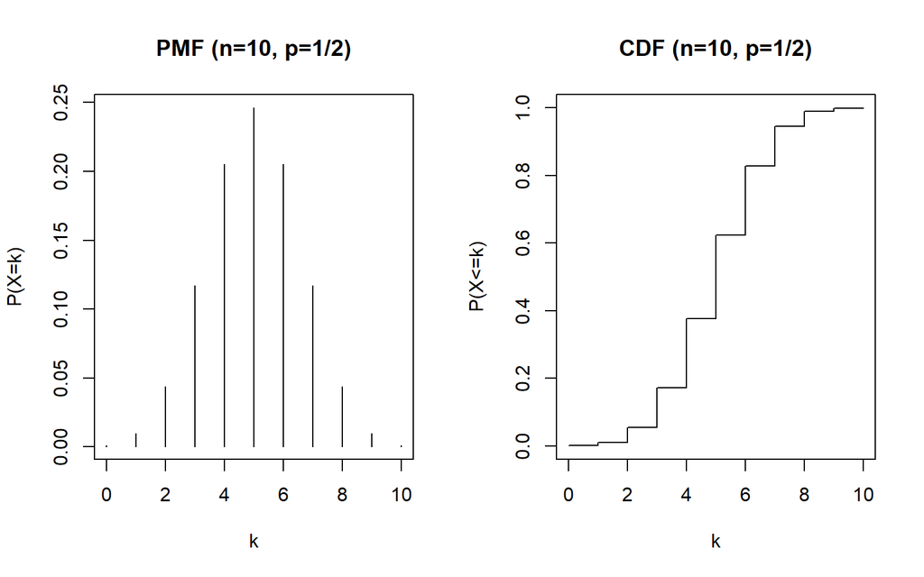

```r
n_a <- 10
p_a <- 1/2
k_a <- 0:n_a

# PMF
pmf_a <- dbinom(k_a, size = n_a, prob = p_a)
# CDF
cdf_a <- pbinom(k_a, size = n_a, prob = p_a)

# Gráficos
par(mfrow = c(1, 2))
plot(k_a, pmf_a, type = "h", main = "PMF (n=10, p=1/2)", xlab = "k", ylab = "P(X=k)")
plot(k_a, cdf_a, type = "s", main = "CDF (n=10, p=1/2)", xlab = "k", ylab = "P(X<=k)")
```

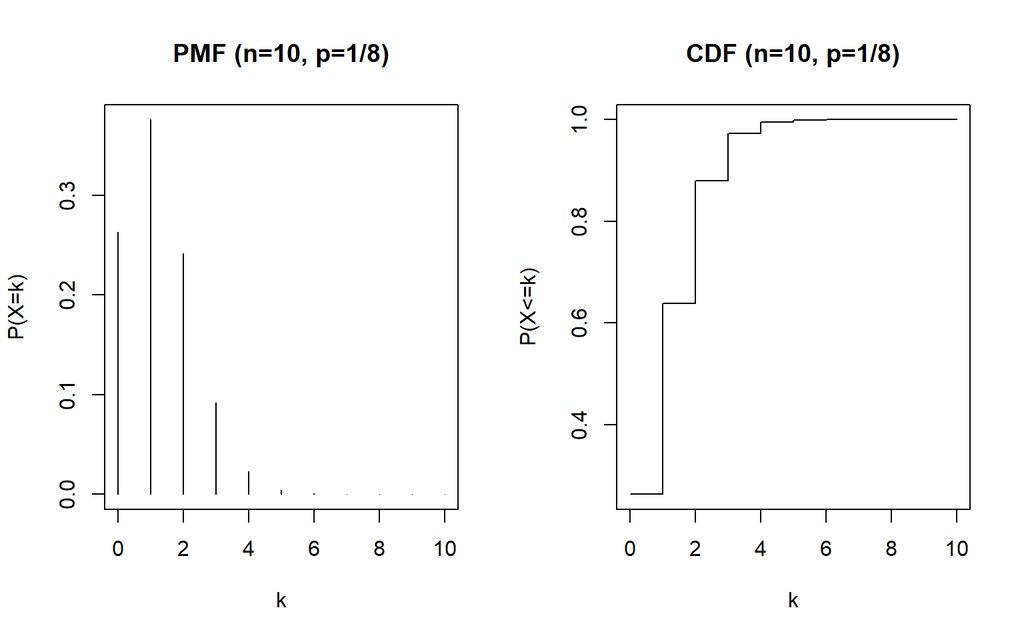

```r
n_b <- 10
p_b <- 1/8
k_b <- 0:n_b

# PMF
pmf_b <- dbinom(k_b, size = n_b, prob = p_b)
# CDF
cdf_b <- pbinom(k_b, size = n_b, prob = p_b)

# Gráficos
par(mfrow = c(1, 2))
plot(k_b, pmf_b, type = "h", main = "PMF (n=10, p=1/8)", xlab = "k", ylab = "P(X=k)")
plot(k_b, cdf_b, type = "s", main = "CDF (n=10, p=1/8)", xlab = "k", ylab = "P(X<=k)")
```

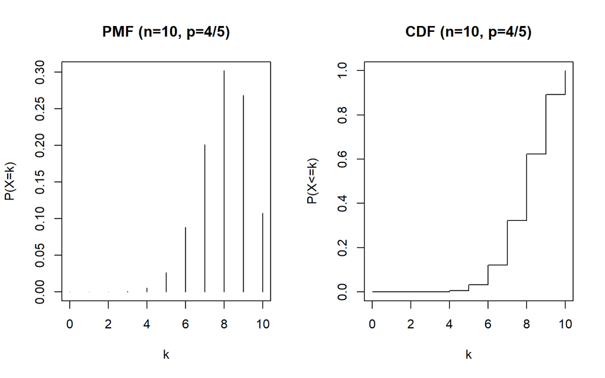

```r
n_c <- 10
p_c <- 4/5
k_c <- 0:n_c

# PMF
pmf_c <- dbinom(k_c, size = n_c, prob = p_c)
# CDF
cdf_c <- pbinom(k_c, size = n_c, prob = p_c)

# Gráficos
par(mfrow = c(1, 2))
plot(k_c, pmf_c, type = "h", main = "PMF (n=10, p=4/5)", xlab = "k", ylab = "P(X=k)")
plot(k_c, cdf_c, type = "s", main = "CDF (n=10, p=4/5)", xlab = "k", ylab = "P(X<=k)")
```

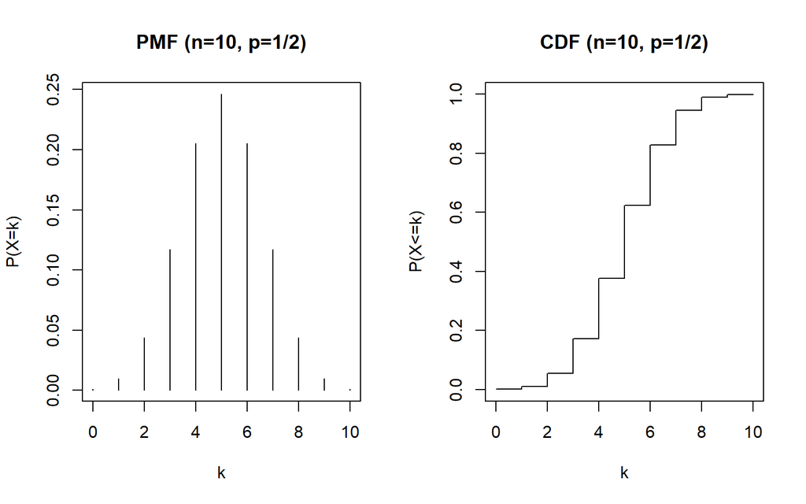

```r
 n_d <- 10
p_d <- 1/2
k_d <- 0:n_d

# PMF
pmf_d <- dbinom(k_d, size = n_d, prob = p_d)
# CDF
cdf_d <- pbinom(k_d, size = n_d, prob = p_d)

# Gráficos
par(mfrow = c(1, 2))
plot(k_d, pmf_d, type = "h", main = "PMF (n=10, p=1/2)", xlab = "k", ylab = "P(X=k)")
plot(k_d, cdf_d, type = "s", main = "CDF (n=10, p=1/2)", xlab = "k", ylab = "P(X<=k)")
```

3. ¿Tiene algún efecto $n$ y $p$ para que la pmf sea simétrica? ¿Cuál?

La simetría de la PMF en una distribución binomial depende de $n$ y $p$. En una distribución binomial, la PMF será simétrica si $p = 0.5$ y $n$ es par. Cuando $p = 0.5$, la probabilidad de éxito es igual a la probabilidad de fracaso en cada ensayo, lo que crea una simetría. Además, cuando $n$ es par, la simetría se refuerza ya que hay un número igual de ensayos en cada lado del valor medio.

4. ¿Qué efecto tiene $p$ en la asimetría?

El valor de $p$ afecta la asimetría de la distribución binomial. Cuanto más alejado esté $p$ de 0.5 (la probabilidad de éxito igual a la probabilidad de fracaso), mayor será la asimetría de la distribución. Cuando $p$ se acerca a 0 o 1, la distribución se vuelve más sesgada hacia la derecha o la izquierda, respectivamente. En otras palabras, la asimetría aumenta a medida que la probabilidad de éxito se aleja de 0.5.

# Variables aletorias continuas

Las variables aleatorias continuas, a diferencia de las discretas, quedan totalmente definidas mediante su PDF y CDF. Existen múltiples variables aleatorias bien conocidas y que sirven para modelar diversos fenómenos. La densidad Gamma está dada por la siguiente ecuación:
$$f_X(x, \alpha, \beta) = \begin{cases}
\frac{\beta^{\alpha}}{\Gamma(\alpha)} x^{\alpha-1} \mbox{e}^{-\beta x}
& x>0\\
0 & x\le 0
\end{cases}$$
donde $\alpha>0$ y $\beta >0$.

## Actividad

1. ¿Qué efecto tiene incrementar $\alpha$? Grafique para contestar.
- Efecto de incrementar $\alpha$ en la densidad Gamma:

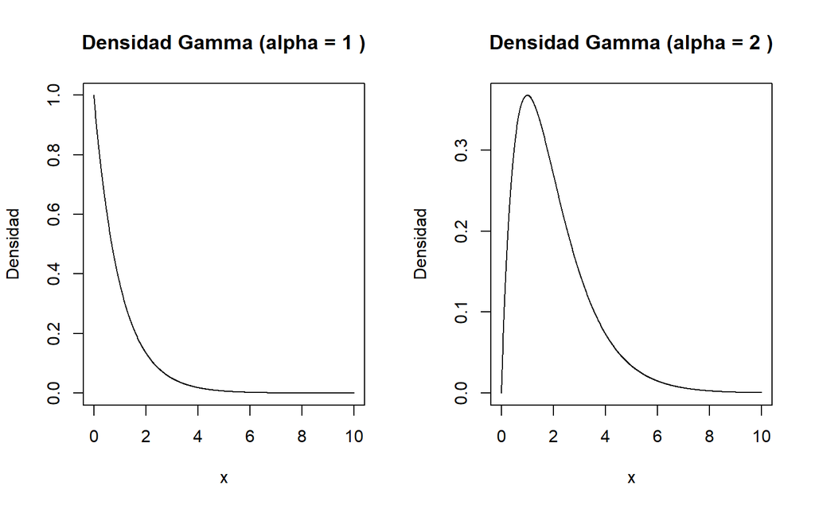

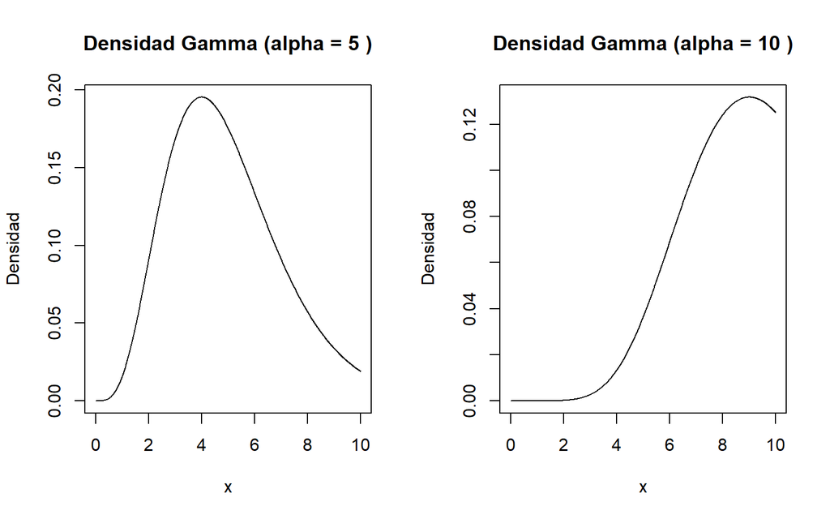

```r
# Definir los valores de x
x <- seq(0, 10, by = 0.01)

# Densidades Gamma para diferentes valores de alpha
alpha_values <- c(1, 2, 5, 10)
beta <- 1

# Crear un gráfico para cada valor de alpha
par(mfrow = c(1, 2))
for (alpha in alpha_values) {
  gamma_density <- (beta^alpha / gamma(alpha)) * x^(alpha - 1) * exp(-beta * x)
  plot(x, gamma_density, type = "l", main = paste("Densidad Gamma (alpha =", alpha, ")"), xlab = "x", ylab = "Densidad")
}
```

- En el código anterior, generamos gráficos de la densidad Gamma con diferentes valores de $\alpha$. Observarás que a medida que incrementas $\alpha$, la densidad se sesga hacia la derecha y su pico se desplaza hacia la derecha.

2. ¿Qué efecto tiene $\beta$ en la forma de la densidad? Grafique para contestar.
- Efecto de $\beta$ en la forma de la densidad Gamma:

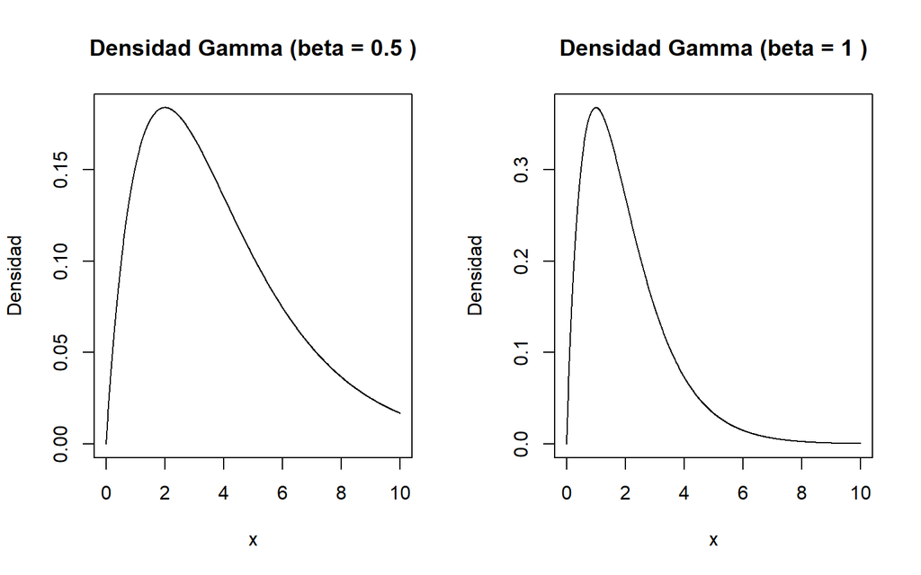

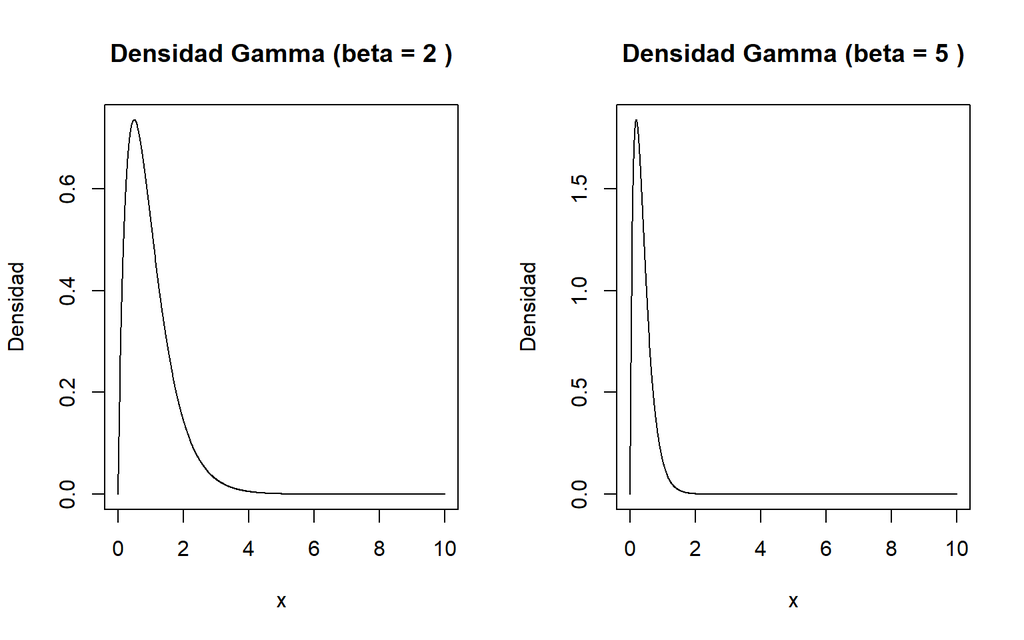

```r
# Definir los valores de x
x <- seq(0, 10, by = 0.01)

# Densidades Gamma para diferentes valores de beta
alpha <- 2
beta_values <- c(0.5, 1, 2, 5)

# Crear un gráfico para cada valor de beta
par(mfrow = c(1, 2))
for (beta in beta_values) {
  gamma_density <- (beta^alpha / gamma(alpha)) * x^(alpha - 1) * exp(-beta * x)
  plot(x, gamma_density, type = "l", main = paste("Densidad Gamma (beta =", beta, ")"), xlab = "x", ylab = "Densidad")
}
```

Observarás que, en la densidad Gamma, $\alpha$ afecta la forma de la densidad y el sesgo hacia la derecha o izquierda, mientras que $\beta$ afecta la concentración alrededor del pico. En la densidad de Cauchy, $\alpha$ controla la ubicación del pico y $\beta$ la “anchura” de la distribución.

Otra variable aleatoria de interés es la variable aleatoria de Cauchy que está definida de la siguiente manera:

$$f_X(x) = \frac{\beta}{\pi ([x-\alpha]^2 + \beta^2)}$$
donde $\alpha \in \mathbb{R}$ y $\beta >0$. Supógamos que $\alpha = 5$.

## Actividad

1. ¿Qué efecto tiene $\beta$ en la función de densidad? Grafique para contestar.

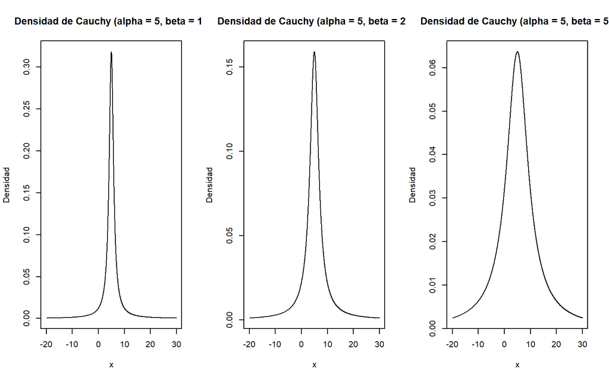

```r
# Definir los valores de x
x <- seq(-20, 30, by = 0.01)

# Densidades de Cauchy para diferentes valores de beta
alpha <- 5
beta_values <- c(1, 2, 5)

# Crear un gráfico para cada valor de beta
par(mfrow = c(1, 3))
for (beta in beta_values) {
  cauchy_density <- beta / (pi * ((x - alpha)^2 + beta^2))
  plot(x, cauchy_density, type = "l", main = paste("Densidad de Cauchy (alpha = 5, beta =", beta, ")"), xlab = "x", ylab = "Densidad")
}
```

Supóngamos que tenemos la siguiente PDF:
$$f_X(x) = \begin{cases}
0 & x < a\\
\frac{2(x-a)}{(b-a)(c-a)} & a \le x < c\\
\frac{2}{b-a} & x=c\\
\frac{2(b-x)}{(b-a)(b-c)} & c < x \le b\\
0 & b < x
\end{cases}$$
donde $a < c < c$.

## Actividad

1. Grafique la densidad triangular cuando $a=0$, $b=4$, $c=2$

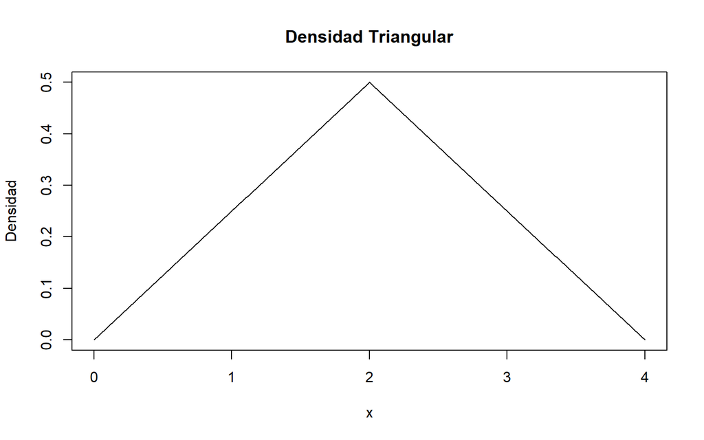

```r
# Definir los valores de a, b y c
a <- 0
b <- 4
c <- 2

# Definir el rango de valores de x
x <- seq(a, b, by = 0.01)

# Inicializar un vector para la densidad triangular
density <- numeric(length(x))

# Calcular la densidad triangular
for (i in 1:length(x)) {
  if (x[i] >= a && x[i] < c) {
    density[i] <- (2 * (x[i] - a)) / ((b - a) * (c - a))
  } else if (x[i] >= c && x[i] <= b) {
    density[i] <- (2 * (b - x[i])) / ((b - a) * (b - c))
  }
}

# Gráfico de la densidad triangular
plot(x, density, type = "l", main = "Densidad Triangular", xlab = "x", ylab = "Densidad")
```

2. Grafique la densidad triangular cuando $a=1$, $c=2$, $b=4$

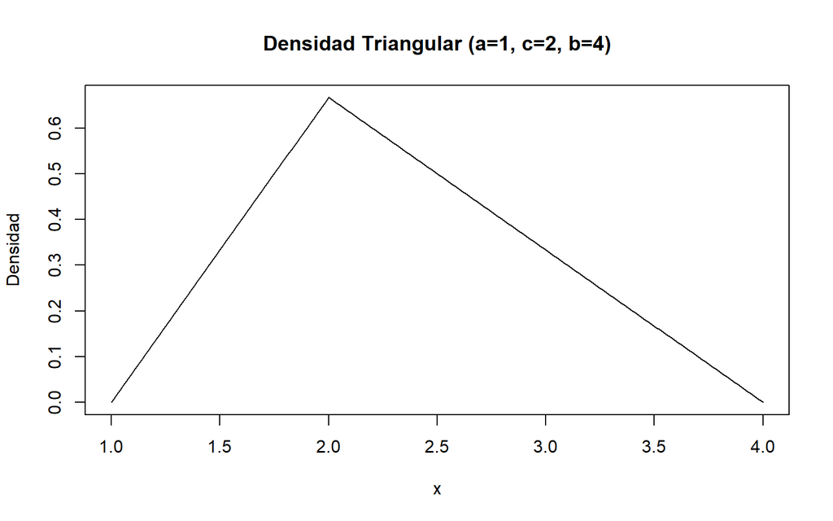

```r
# Definir los valores de a, b y c
a <- 1
b <- 4
c <- 2

# Definir el rango de valores de x
x <- seq(a, b, by = 0.01)

# Inicializar un vector para la densidad triangular
density <- numeric(length(x))

# Calcular la densidad triangular
for (i in 1:length(x)) {
  if (x[i] >= a && x[i] < c) {
    density[i] <- (2 * (x[i] - a)) / ((b - a) * (c - a))
  } else if (x[i] >= c && x[i] <= b) {
    density[i] <- (2 * (b - x[i])) / ((b - a) * (b - c))
  }
}

# Gráfico de la densidad triangular
plot(x, density, type = "l", main = "Densidad Triangular (a=1, c=2, b=4)", xlab = "x", ylab = "Densidad")
```

3. Grafique la densidad triangular cuando $a=-1$, $c=0$, $b=1$

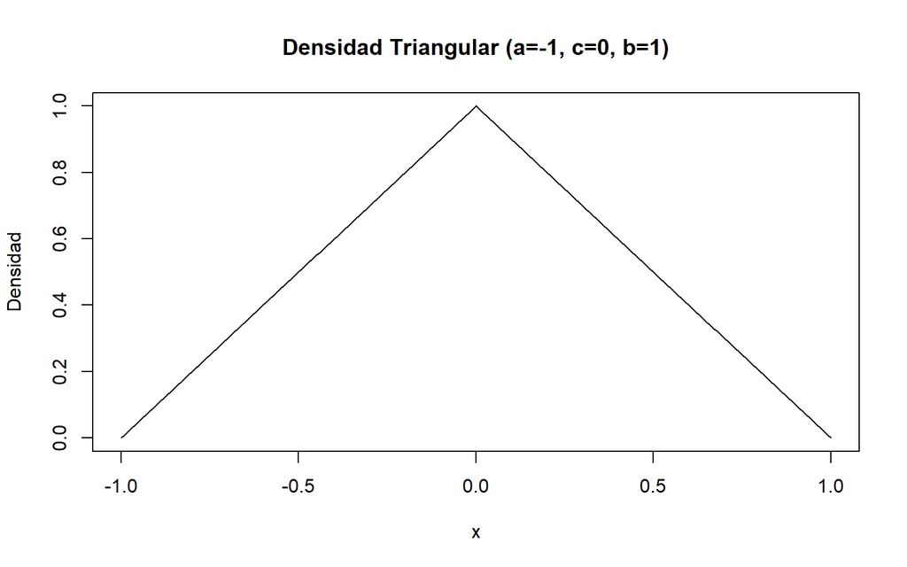

```r
# Definir los valores de a, b y c
a <- -1
b <- 1
c <- 0

# Definir el rango de valores de x
x <- seq(a, b, by = 0.01)

# Inicializar un vector para la densidad triangular
density <- numeric(length(x))

# Calcular la densidad triangular
for (i in 1:length(x)) {
  if (x[i] >= a && x[i] < c) {
    density[i] <- (2 * (x[i] - a)) / ((b - a) * (c - a))
  } else if (x[i] >= c && x[i] <= b) {
    density[i] <- (2 * (b - x[i])) / ((b - a) * (b - c))
  }
}

# Gráfico de la densidad triangular
plot(x, density, type = "l", main = "Densidad Triangular (a=-1, c=0, b=1)", xlab = "x", ylab = "Densidad")
```

Tanto `R` como `python` nos permiten calcular integrales usando los comandos básicos o bién usando sistemas de cómputo algebraíco. R, por ejemplo, puede utilizar un sistema llamado `Ryacas` que permite hacer muchos cálculos de forma simbólica. Ahora, consideremos que tenemos la siguiente PDF:

$$f_X(x) = \begin{cases}
\mbox{e}^{-x} & x \ge 0\\
0 & \mbox{resto}
\end{cases}$$

## Actividad

Calcular, usando los comando de integración o `Ryacas` o `python` las siguientes probabilidades usando la PDF de arriba:

1. $P(X>1)$
2. $P(2 < X \le 4)$
3. $P(X \le 2)$

```r
# Definir la función de densidad f_X(x)
pdf <- function(x) {
  ifelse(x >= 0, exp(-x), 0)
}

# Calcular la probabilidad P(X > 1)
prob_1 <- 1 - integrate(pdf, lower = 0, upper = 1)$value
prob_1
```

```
## [1] 0.3678794
```

```r
# Calcular la probabilidad P(2 < X ≤ 4)
prob_2 <- integrate(pdf, lower = 2, upper = 4)$value
prob_2
```

```
## [1] 0.1170196
```

```r
# Calcular la probabilidad P(X ≤ 2)
prob_3 <- integrate(pdf, lower = 0, upper = 2)$value
prob_3
```

```
## [1] 0.8646647
```

Finalmente, supongamos que tenemos la siguiente PDF:

$$f_X(x) = \frac{1}{\sqrt{2\pi}}\mbox{e}^{-\frac{(x-3)^2}{2}}$$

## Actividad

1. Graficar $f_X(3+x)$.
2. Graficar $f_X(3-x)$.
3. Que hay en común entre estas dos gráficas y qué se puede inferir de $f_X(3+x)$ y $f_X(3-x)$

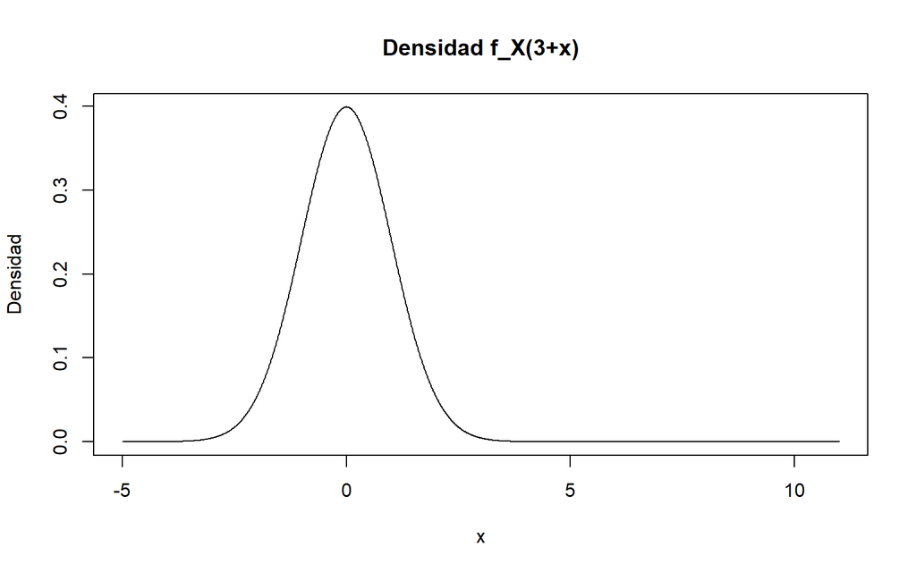

```r
# Definir la función de densidad f_X(x)
pdf <- function(x) {
  1 / sqrt(2 * pi) * exp(-((x - 3)^2 / 2))
}

# Definir el rango de valores de x
x <- seq(-5, 11, by = 0.01)

# Calcular la densidad f_X(3+x)
pdf_plus <- pdf(3 + x)

# Gráfico de f_X(3+x)
plot(x, pdf_plus, type = "l", main = "Densidad f_X(3+x)", xlab = "x", ylab = "Densidad")
```

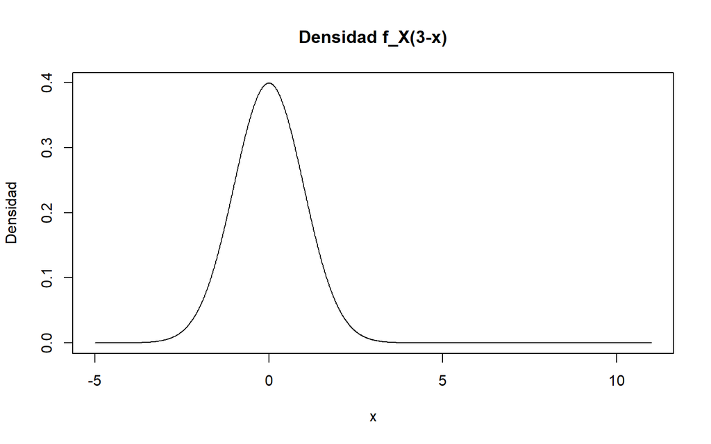

```r
# Calcular la densidad f_X(3-x)
pdf_minus <- pdf(3 - x)

# Gráfico de f_X(3-x)
plot(x, pdf_minus, type = "l", main = "Densidad f_X(3-x)", xlab = "x", ylab = "Densidad")
```

## Fecha de entrega: miércoles 18 de octubre de 2023 a través de Moodle.